# 26TB - Third interim analysis (BLINDED VERSION)

Code preparation: Trinh Dong, Thao Le, and Ronald Geskus; DSMB statistician: Sarah Walker

2019-03-22

# Background

### Table 1: Summary of baseline characteristics at study entry

Characteristic

n

Summary statistic

n

Summary statistic

Dummy A (N=102)

Dummy B (N=100)

Age

102

36 (30,41)

100

35 (29,40)

Sex

102

100

1/102 (1%)

1/100 (1%)

- F

21/102 (21%)

22/100 (22%)

- M

80/102 (78%)

77/100 (77%)

TBM Grade

102

100

- 1

37/102 (36%)

39/100 (39%)

- 2

48/102 (47%)

44/100 (44%)

- 3

17/102 (17%)

17/100 (17%)

Site

102

100

- HTD

32/102 (31%)

34/100 (34%)

- PNT

50/102 (49%)

48/100 (48%)

- Cipto

18/102 (18%)

15/100 (15%)

- Persahabatan

2/102 (2%)

3/100 (3%)

Diagnostic Score

100

100

- definite TBM

43/100 (43%)

36/100 (36%)

- probable TBM

44/100 (44%)

51/100 (51%)

- possible TBM

12/100 (12%)

10/100 (10%)

- confirmed other diagnosis

1/100 (1%)

3/100 (3%)

ART Status

102

100

- <= 3 months of ART

12/102 (12%)

18/100 (18%)

- > 3 months of ART

23/102 (23%)

22/100 (22%)

- ART naive

47/102 (46%)

45/100 (45%)

- Undetermined

2/102 (2%)

1/100 (1%)

- Unknown

18/102 (18%)

14/100 (14%)

CD4

87

22 (10,110)

91

22 (8,57)

Fasting Blood Glucose

83

6 (5,9)

85

7 (6,10)

Diabetes

102

100

1/102 (1%)

0/100 (0%)

- N

97/102 (95%)

96/100 (96%)

- UNK

0/102 (0%)

1/100 (1%)

- Y

4/102 (4%)

3/100 (3%)

* N = number of patients included in that statistic. Summary statistic = the median (IQR) value for continuous data, and the number and frequency (%) of patients with the characteristic for categorical data. Definite TBM = positive acid fast bacilli (AFB) on CSF Ziehl Neelson stain, OR positive CSF TB GeneXpert test, OR positive CSF TB culture. Probable or possible TBM = patient treated as TBM, AND patient does not meet criteria for ‘definite TBM’ (above), AND no additional confirmed brain infection (as below). Confirmed non-TBM = microbiologically confirmed other brain infection. Confirmed additional brain infection includes positive CSF India Ink stain, OR CSF cryptococcal antigen, OR positive blood cryptococcal antigen, OR positive CSF bacterial Gram stain, OR positive CSF bacterial culture, OR positive CSF viral or helminth PCR test.

† ART status of a patient is unknown if i) they are/was on ART treatment and the start ART date is missing; or ii) their ART status is unknown.

# Overall survival

The primary endpoint is overall survival, i.e. time from randomisation to death, until 12 months of follow-up.

### Table 2: Table for Cox models

Subgroup

Dummy A (n=102)

Dummy B (n=100)

Comparison

Test for proportional hazards

Test for heterogeneity

events/n

events/n

HR (95%CI); p-value

p-value

p-value

All patients

41/101

45/100

1.16 (0.76-1.77); p=0.49

0.57

TBM Grade

0.79

- 1

7/37

11/39

1.55 (0.60-3.99); p=0.37

0.79

- 2

20/48

20/44

1.16 (0.62-2.16); p=0.64

0.49

- 3

14/16

14/17

1.03 (0.49-2.18); p=0.94

0.39

Site

0.63

- HTD

13/32

17/34

1.43 (0.69-2.94); p=0.34

0.25

- PNT

20/49

19/48

0.90 (0.48-1.70); p=0.75

0.50

- Cipto

8/18

8/15

1.37 (0.51-3.67); p=0.53

0.62

- Persahabatan

0/2

1/3

1142066058.23 (0.00-Inf); p=1.00

NA

### Kaplan-Meier plots

Figure 1: Kaplan-Meier curves of overall survival.

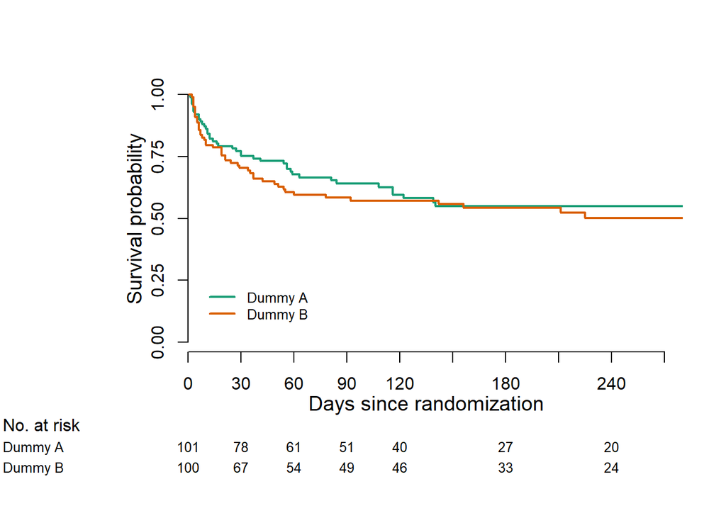

### Table 3: Follow up in patients not known to have died

Dummy A

Dummy B

N=102

N=100

Characteristic

n

Summary statistic

n

Summary statistic

Follow-up categories

60

55

- death

0/60 (0%)

0/55 (0%)

- No longer in follow-up

1/60 (2%)

1/55 (2%)

- Ongoing follow-up

59/60 (98%)

54/55 (98%)

- Exited the trial

0/60 (0%)

0/55 (0%)

N = number of patients with that characteristic, shown with the corrsponding % of patients within that intevention group.

# Requirement for corticosteroids

### Table 4: Requirement for open label corticosteroids during period of study drug

|  | Dummy A N = 102 | Dummy B N = 100 |
| --- | --- | --- |
| All patients | 11 (11%) | 16 (16%) |
| **MRC Grade** |  |  |
| 1 | 0 (0%) | 5 (5%) |
| 2 | 9 (9%) | 8 (8%) |
| 3 | 2 (2%) | 3 (3%) |
| **Site** |  |  |
| HTD | 9 (9%) | 12 (12%) |
| PNT | 1 (1%) | 1 (1%) |
| Cipto | 1 (1%) | 3 (3%) |
| Persahabatan | 0 (0%) | 0 (0%) |
| **Reason** |  |  |
| fallgcs | 2 (2%) | 6 (6%) |
| neudeficit | 1 (1%) | 4 (4%) |
| seizures | 0 (0%) | 1 (1%) |
| tuberculoma | 1 (1%) | 4 (4%) |
| hydrocephalus | 2 (2%) | 0 (0%) |
| vasculitis | 0 (0%) | 1 (1%) |
| neuroiris | 1 (1%) | 1 (1%) |
| extraneuiris | 0 (0%) | 1 (1%) |

N = number of patients with that characteristic  
Data represented as N (%) of all patients receiving that intervention.  
All other reasons here are Herniation.

### Table 5: Requirement for open label corticosteroids after completion of study drug

|  | Dummy A N = 102 | Dummy B N = 100 |
| --- | --- | --- |
| All patients | 5 (5%) | 5 (5%) |
| **MRC Grade** |  |  |
| 1 | 1 (1%) | 1 (1%) |
| 2 | 3 (3%) | 3 (3%) |
| 3 | 1 (1%) | 1 (1%) |
| **Site** |  |  |
| HTD | 4 (4%) | 3 (3%) |
| PNT | 1 (1%) | 2 (2%) |
| Cipto | 0 (0%) | 0 (0%) |
| **Reason** |  |  |
| Persahabatan | 0 (0%) | 0 (0%) |
| Brain lesions significantly increased on MRI scan | 1 (1%) | 0 (0%) |
| DAU TK KHU TRU MOI, TON THUONG MRI TANG HON | 1 (1%) | 0 (0%) |
| Neurological IRIS | 0 (0%) | 1 (1%) |
| Non-neurological IRIS | 1 (1%) | 1 (1%) |
| TANG AP LUC NOI SO | 1 (1%) | 0 (0%) |
| TON THUONG VUNG TUY CO | 0 (0%) | 1 (1%) |
| Tuberculoma | 0 (0%) | 1 (1%) |
| Tuberculoma with high CSF protein | 1 (1%) | 0 (0%) |
| WORSENING SYMPTOMS AND CSF PARAMETERS OF TB MENINGITIS | 0 (0%) | 1 (1%) |

Completion of study drug is defined as completion of 6 weeks of study drug for enrollment Grade 1, or completion of 8 weeks of study drug for enrollment Grades 2 or 3.  
N = number of patients with that characteristic  
Data represented as N (%) of all patients receiving that intervention

# Drug induced liver injury (DILI) study

## Summary of DILI strategy by studies and treatment arm

### Table 6A: DILI participants by Study

Dummy A

Dummy B

Study

14

9

- 26TB

7/14 (50%)

6/9 (67%)

- 27TB

7/14 (50%)

3/9 (33%)

### Table 6B: DILI participants in 27TB by LTA4H Genotype

Dummy A

Dummy B

LTA4H Genotype

7

3

- CC

2/7 (29%)

2/3 (67%)

- CT

5/7 (71%)

1/3 (33%)

### Table 6C: DILI participants in both 26TB and 27TB by Strategy

Dummy A

Dummy B

DILI Strategy

14

9

- Monitor

4/14 (29%)

3/9 (33%)

- Stop Z

3/14 (21%)

4/9 (44%)

- Stop RHZ

7/14 (50%)

2/9 (22%)

## Table 7: Summary of liver parameters and survival of patients in the DILI study

Treatment arm

Dummy A

Dummy B

DILI strategy

Monitor (N=4)

Stop Z (N=3)

Stop RHZ (N=7)

Monitor (N=3)

Stop Z (N=4)

Stop RHZ (N=2)

Characteristic

n

Summary statistic

n

Summary statistic

n

Summary statistic

n

Summary statistic

n

Summary statistic

n

Summary statistic

**Entry liver tests**

ALT

4

225 (168,287)

3

244 (199,250)

7

187 (128,208)

3

201 (138,280)

4

112 (106,138)

2

143 (108,178)

Bilirubin

4

19 (16,22)

3

17 (13,18)

6

22 (17,55)

2

27 (23,31)

4

40 (17,70)

2

61 (60,63)

INR

2

1 (1,1)

2

1 (1,1)

1

1 (1,1)

2

1 (1,1)

2

1 (1,2)

2

1 (1,1)

**Peak liver tests**

ALT Peak

4

328 (278,460)

3

244 (243,250)

5

178 (78,209)

3

201 (138,280)

4

174 (114,241)

2

144 (109,178)

Bilirubin Peak

4

30 (24,35)

3

19 (19,33)

5

62 (19,65)

3

19 (15,27)

4

47 (31,80)

2

82 (75,89)

INR Peak

2

1 (1,1)

2

1 (1,1)

3

1 (1,1)

2

1 (1,1)

3

1 (1,1)

2

3 (2,3)

**Surival information**

Total Death

3

1

4

3

3

2

- No

2/3 (67%)

1/1 (100%)

2/4 (50%)

1/3 (33%)

2/3 (67%)

2/2 (100%)

- Yes

1/3 (33%)

0/1 (0%)

2/4 (50%)

2/3 (67%)

1/3 (33%)

0/2 (0%)

Death during DILI

3

1

4

3

3

2

- No

2/3 (67%)

1/1 (100%)

3/4 (75%)

2/3 (67%)

2/3 (67%)

2/2 (100%)

- Yes

1/3 (33%)

0/1 (0%)

1/4 (25%)

1/3 (33%)

1/3 (33%)

0/2 (0%)

**Death**

Days to death from TB drug start

1

25 (25,25)

0

NA (NA,NA)

2

70 (62,77)

2

26 (20,32)

1

36 (36,36)

0

NA (NA,NA)

Days to death from ART start*

0

NA (NA,NA)

0

NA (NA,NA)

2

289 (184,394)

0

NA (NA,NA)

0

NA (NA,NA)

0

NA (NA,NA)

Days to death from DILI start

1

18 (18,18)

0

NA (NA,NA)

2

40 (24,56)

2

10 (7,14)

1

15 (15,15)

0

NA (NA,NA)

* 26TB only

# Adverse event

The number of patients with any adverse events and specific events, respectively, are summarised and informally compared between the two treatment arms based on Fisher’s exact test

## Table 8: Summary of clinical grade 3&4 adverse events

In the following table, we excluded patient with missing information for the aforementioned information.

Dummy A (n=102)

Dummy B (n=100)

Comparison

Adverse event name

n.pt.1

n.ae.1

n.pt.2

n.ae.2

(p value)

Any selected AE

60 (59%)

132

53 (53%)

115

0.479

Kaposi’s sarcoma

0 (0%)

0

0 (0%)

0

Worsening level of consciousness (go to question Number 4) (Fall in GCS = 2points, for = 48hrs)

13 (13%)

14

17 (17%)

18

0.433

New focal neurological sign (go to question Number 5) (lasting >24 hours)

1 (1%)

1

4 (4%)

4

0.209

Hyponatraemia requiring intervention or medically important (go to question Number 6) (If yes - lowest value recorded)

15 (15%)

19

13 (13%)

13

0.839

Hypoglycaemia requiring intervention or medically important (go to question Number 7) (If yes - lowest value recorded)

1 (1%)

1

0 (0%)

0

1

Elevation of blood transaminase concentrations =3 times the upper limit of normal with symptoms and signs of hepatitis (vomiting, abdominal pain, jaundice)  
*If yes, go to DILI study sheet (record action whether or not patient enrolled in DILI s*

3 (3%)

5

3 (3%)

3

1

Elevation of blood transaminases =5 times the upper limit of normal or a rise in serum bilirubin >2.0mg/dL (>34 µmol/L) without symptoms  
*If yes, go to DILI study sheet (record action whether or not patient enrolled in DILI study)*

7 (7%)

7

3 (3%)

4

0.332

HIV Stage 4 illness (go to question number 8)  
(other than TBM) *please list as appropriate in setting

1 (1%)

2

1 (1%)

1

1

Neurological IRIS (go to question number 9)  
*(complete IRIS CRF if neurological IRIS suspected)*

2 (2%)

2

2 (2%)

2

1

CAR08

1 (1%)

2

0 (0%)

0

1

DIARRHEA

1 (1%)

1

0 (0%)

0

1

LAB 01

3 (3%)

4

4 (4%)

4

0.72

INF 08

1 (1%)

1

0 (0%)

0

1

HA THAP

0 (0%)

0

1 (1%)

2

0.495

VIEM PHOI ACINETOBACTER BAUMANNNII

0 (0%)

0

1 (1%)

1

0.495

THIEU MAU

2 (2%)

2

1 (1%)

1

1

SKI01

1 (1%)

1

0 (0%)

0

1

HAE 01

3 (3%)

4

1 (1%)

1

0.621

LAB 03

0 (0%)

0

2 (2%)

2

0.244

LAB 07

1 (1%)

1

1 (1%)

1

1

HAE 02

1 (1%)

1

1 (1%)

1

1

Death

2 (2%)

2

2 (2%)

2

1

HEADACHE

1 (1%)

1

1 (1%)

1

1

INF 03 (PNEUMONIA)

0 (0%)

0

1 (1%)

1

0.495

NEU-14:Hemorrhagic stroke

1 (1%)

1

0 (0%)

0

1

Death suspected due to sepsis

1 (1%)

1

0 (0%)

0

1

RES-01

0 (0%)

0

1 (1%)

1

0.495

CAR 08 sudden cardiac arrest

1 (1%)

1

0 (0%)

0

1

TANG AP LUC NOI SO: Y THUC GIAM, MACH CHAM 45L/PH, DAU MAT TROI MOC

0 (0%)

0

1 (1%)

1

0.495

GAS 03

1 (1%)

1

2 (2%)

2

0.619

CO CON NGUNG THO (DOA TUT NAO)

0 (0%)

0

1 (1%)

1

0.495

THEO DOI NHIEM TRUNG HUYET

1 (1%)

1

2 (2%)

2

0.619

DYSPNEA

1 (1%)

1

0 (0%)

0

1

INF 09 (septic shock with pneumonia, severe acidosis, thrombocytopenia, hypoalbuminemia)

1 (1%)

1

0 (0%)

0

1

NGUNG TIM, DAN DONG TU (NGHI TUT NAO)

0 (0%)

0

1 (1%)

1

0.495

MAT MAU CAP

1 (1%)

1

0 (0%)

0

1

SAC THUC AN

1 (1%)

1

1 (1%)

1

1

ANEMIA

1 (1%)

1

1 (1%)

1

1

RES 01

0 (0%)

0

1 (1%)

1

0.495

GAS 08:Hematemesis-melena

1 (1%)

2

0 (0%)

0

1

TANG AP LUC NOI SO

0 (0%)

0

1 (1%)

1

0.495

SKI 06: Allergic drug eruption

0 (0%)

0

1 (1%)

1

0.495

TANG BILIRUBIN GAP 5 LAN GIOI HAN TREN + VANG DA, NON OI, DAU HA SUON (P)

0 (0%)

0

1 (1%)

1

0.495

CAR 08 Cardiogenic shock due to AFrVR dd/ septic shock with thrombocytopenia, increased APTT,PT and transaminase enzyme

0 (0%)

0

1 (1%)

1

0.495

TIEU MAU

1 (1%)

1

0 (0%)

0

1

NHUC DAU, OI

1 (1%)

1

0 (0%)

0

1

RES01 RESPIRATORY FAILURE

2 (2%)

2

2 (2%)

2

1

PHAN UNG PHAN VE

0 (0%)

0

1 (1%)

1

0.495

GAS02

0 (0%)

0

1 (1%)

1

0.495

XUAT HUYET TIEU HOA TREN

2 (2%)

2

2 (2%)

2

1

SEPSIC SHOCK INF08

1 (1%)

1

0 (0%)

0

1

PHU CHAN + BANG BUNG

0 (0%)

0

1 (1%)

1

0.495

HO KHAC DAM

0 (0%)

0

1 (1%)

1

0.495

HA KALI

0 (0%)

0

1 (1%)

1

0.495

LAB 02

0 (0%)

0

1 (1%)

1

0.495

SOT + OI

1 (1%)

1

0 (0%)

0

1

TIEU CHAY NHIEM TRUNG

1 (1%)

1

0 (0%)

0

1

GAS 10 Hematemesis with anemia

1 (1%)

1

0 (0%)

0

1

Respiratory Failure

0 (0%)

0

1 (1%)

1

0.495

RES 01 due to miliary TB dd/sepsis with thrombocytopenia

1 (1%)

1

0 (0%)

0

1

HA KALI MAU

1 (1%)

1

1 (1%)

1

1

Death at home

1 (1%)

2

0 (0%)

0

1

GAS 02

1 (1%)

1

0 (0%)

0

1

CON01 FEVER

0 (0%)

0

2 (2%)

2

0.244

CHOANG, NGHI CHOANG NHIEM TRUNG

1 (1%)

1

0 (0%)

0

1

INF 09 (septic shock with thrombocytopenia suspected due to urinary tract infection)

0 (0%)

0

1 (1%)

1

0.495

DAN DONG TU BEN (P), MAT PXAS

0 (0%)

0

1 (1%)

1

0.495

CON01 (FEVER)

1 (1%)

1

0 (0%)

0

1

LIET RUOT, TAC RUOT

1 (1%)

1

0 (0%)

0

1

SUY TUAN HOAN

0 (0%)

0

1 (1%)

1

0.495

RES02 RESPIRATORY FAILURE

0 (0%)

0

1 (1%)

1

0.495

SUY THAN CAP

2 (2%)

2

0 (0%)

0

0.498

NEU10 HEADACHE

1 (1%)

1

0 (0%)

0

1

DAN NAO THAT

1 (1%)

1

0 (0%)

0

1

THO CO KEO -> DAT NOI KHI QUAN/THO MAY

1 (1%)

1

0 (0%)

0

1

TUT HA

1 (1%)

1

0 (0%)

0

1

LOET NHIEU VUNG XUONG CUNG

0 (0%)

0

1 (1%)

1

0.495

SUY HO HAP

3 (3%)

3

4 (4%)

5

0.72

SKI 02 (RASH OF UNKNOWN ETIOLOGY)

0 (0%)

0

1 (1%)

1

0.495

TD SOC NHIEM TRUNG

0 (0%)

0

1 (1%)

1

0.495

NHIP NHANH XOANG

0 (0%)

0

1 (1%)

1

0.495

SOT

0 (0%)

0

1 (1%)

1

0.495

SHOCK - THEO DOI REPSIS SHOCK

1 (1%)

1

0 (0%)

0

1

TUT NAO

1 (1%)

1

0 (0%)

0

1

CAR 04

1 (1%)

1

0 (0%)

0

1

NEU 09 (SEIZURE)

0 (0%)

0

1 (1%)

1

0.495

CHOANG (CHUA RO NGUYEN NHAN)

0 (0%)

0

1 (1%)

1

0.495

TU VONG

0 (0%)

0

1 (1%)

1

0.495

NHIEM TRUNG TIEU

1 (1%)

1

0 (0%)

0

1

DAU DAU + SOT

1 (1%)

1

0 (0%)

0

1

VIEM PHOI

1 (1%)

1

0 (0%)

0

1

DAT SONDE DD

1 (1%)

1

0 (0%)

0

1

PNEUMOTHORAX RES03

1 (1%)

1

0 (0%)

0

1

INF 04 DIARRHOEA

1 (1%)

1

0 (0%)

0

1

INF03 PNEUMONIA

1 (1%)

1

0 (0%)

0

1

OI + DAU BUNG

1 (1%)

1

0 (0%)

0

1

GASTROINTESTINAL HEMORRHAGE

0 (0%)

0

1 (1%)

1

0.495

LAB03 HYPOKALEAMIA

1 (1%)

1

0 (0%)

0

1

TRAN DICH MANG PHOI (T)

1 (1%)

1

0 (0%)

0

1

NGUNG TIM

1 (1%)

1

0 (0%)

0

1

RASH

0 (0%)

0

1 (1%)

1

0.495

HAE01 ANAEMIA

0 (0%)

0

1 (1%)

1

0.495

DAU NGUC

1 (1%)

1

0 (0%)

0

1

HAE02:Thrombocytopenia lowest value (34.000)

1 (1%)

1

0 (0%)

0

1

ALL 07

0 (0%)

0

1 (1%)

1

0.495

NEU 09

1 (1%)

1

0 (0%)

0

1

CAR05 CANDIDA FAILURE

1 (1%)

1

0 (0%)

0

1

OI

0 (0%)

0

1 (1%)

1

0.495

GIAM TIEU CAU

1 (1%)

1

0 (0%)

0

1

SHOCK - THEO DOI SEPSIS SHOCK

0 (0%)

0

1 (1%)

1

0.495

GI?M TI?U C?U

0 (0%)

0

1 (1%)

1

0.495

SKI01 (CO-TRIMOXAZOLE RELATED EASE)

1 (1%)

1

0 (0%)

0

1

HAE01 (ANAEMIA)

1 (1%)

1

0 (0%)

0

1

LIVER ABSCESSES

1 (1%)

1

0 (0%)

0

1

ULN = Upper limit of normal

N.pt = the number of patients with at least one adverse event (% of all patients receiving the same intervention)

N.ae = number of adverse event episodes

## Table 9: Summary of serious adverse events

Dummy A (n=102)

Dummy B (n=100)

Comparison

Adverse event name

n.pt.1

n.ae.1

n.pt.2

n.ae.2

(p value)

Any selected AE

72 (71%)

152

66 (66%)

141

0.546

Kaposi’s sarcoma

0 (0%)

0

0 (0%)

0

Worsening level of consciousness (go to question Number 4) (Fall in GCS = 2points, for = 48hrs)

17 (17%)

18

24 (24%)

25

0.223

New focal neurological sign (go to question Number 5) (lasting >24 hours)

4 (4%)

4

6 (6%)

6

0.535

Hyponatraemia requiring intervention or medically important (go to question Number 6) (If yes - lowest value recorded)

20 (20%)

23

17 (17%)

17

0.717

Hypoglycaemia requiring intervention or medically important (go to question Number 7) (If yes - lowest value recorded)

2 (2%)

2

0 (0%)

0

0.498

Elevation of blood transaminase concentrations =3 times the upper limit of normal with symptoms and signs of hepatitis (vomiting, abdominal pain, jaundice)  
*If yes, go to DILI study sheet (record action whether or not patient enrolled in DILI s*

4 (4%)

6

4 (4%)

5

1

Elevation of blood transaminases =5 times the upper limit of normal or a rise in serum bilirubin >2.0mg/dL (>34 µmol/L) without symptoms  
*If yes, go to DILI study sheet (record action whether or not patient enrolled in DILI study)*

8 (8%)

8

3 (3%)

4

0.214

HIV Stage 4 illness (go to question number 8)  
(other than TBM) *please list as appropriate in setting

1 (1%)

2

1 (1%)

1

1

Neurological IRIS (go to question number 9)  
*(complete IRIS CRF if neurological IRIS suspected)*

3 (3%)

3

2 (2%)

2

1

Non-neurological IRIS (go to question number 10)

1 (1%)

1

1 (1%)

1

1

CAR08

1 (1%)

2

0 (0%)

0

1

TUT HUYET AP

1 (1%)

1

0 (0%)

0

1

DIARRHEA

1 (1%)

1

0 (0%)

0

1

INF 08

1 (1%)

1

0 (0%)

0

1

HA THAP

2 (2%)

2

3 (3%)

4

0.681

SUY HO HAP

4 (4%)

4

6 (6%)

7

0.535

SOC, HUYET AP THAP

0 (0%)

0

1 (1%)

1

0.495

CO GIAT

0 (0%)

0

1 (1%)

1

0.495

VIEM PHOI ACINETOBACTER BAUMANNNII

0 (0%)

0

1 (1%)

1

0.495

SKI01

1 (1%)

1

0 (0%)

0

1

TUT NAO THAI DUONG 2 BEN

0 (0%)

0

1 (1%)

1

0.495

LAB 03

0 (0%)

0

1 (1%)

1

0.495

Death

2 (2%)

2

2 (2%)

2

1

HEADACHE

1 (1%)

1

1 (1%)

1

1

INF 03 (PNEUMONIA)

0 (0%)

0

1 (1%)

1

0.495

NEU-14:Hemorrhagic stroke

1 (1%)

1

0 (0%)

0

1

Death suspected due to sepsis

1 (1%)

1

0 (0%)

0

1

RES-01

0 (0%)

0

1 (1%)

1

0.495

CAR 08 sudden cardiac arrest

1 (1%)

1

0 (0%)

0

1

HAE 02

0 (0%)

0

1 (1%)

1

0.495

NOI SAN DO, NGUA TOAN THAN

0 (0%)

0

1 (1%)

1

0.495

TANG AP LUC NOI SO: Y THUC GIAM, MACH CHAM 45L/PH, DAU MAT TROI MOC

0 (0%)

0

1 (1%)

1

0.495

GAS 03

1 (1%)

1

2 (2%)

2

0.619

CO CON NGUNG THO (DOA TUT NAO)

0 (0%)

0

1 (1%)

1

0.495

THEO DOI NHIEM TRUNG HUYET

1 (1%)

1

2 (2%)

2

0.619

DYSPNEA

1 (1%)

1

0 (0%)

0

1

INF 09 (septic shock with pneumonia, severe acidosis, thrombocytopenia, hypoalbuminemia)

1 (1%)

1

0 (0%)

0

1

NGUNG TIM, DAN DONG TU (NGHI TUT NAO)

0 (0%)

0

1 (1%)

1

0.495

MAT MAU CAP

1 (1%)

1

0 (0%)

0

1

SAC THUC AN

1 (1%)

1

1 (1%)

1

1

ANEMIA

1 (1%)

1

1 (1%)

1

1

RES 01

0 (0%)

0

1 (1%)

1

0.495

GAS 08:Hematemesis-melena

1 (1%)

2

0 (0%)

0

1

TANG AP LUC NOI SO

0 (0%)

0

1 (1%)

1

0.495

SKI 06: Allergic drug eruption

0 (0%)

0

1 (1%)

1

0.495

TANG BILIRUBIN GAP 5 LAN GIOI HAN TREN + VANG DA, NON OI, DAU HA SUON (P)

0 (0%)

0

1 (1%)

1

0.495

TD ABCES VUNG MONG

0 (0%)

0

1 (1%)

1

0.495

CAR 08 Cardiogenic shock due to AFrVR dd/ septic shock with thrombocytopenia, increased APTT,PT and transaminase enzyme

0 (0%)

0

1 (1%)

1

0.495

TIEU MAU

1 (1%)

1

0 (0%)

0

1

NHUC DAU, OI

1 (1%)

1

0 (0%)

0

1

RES01 RESPIRATORY FAILURE

2 (2%)

2

1 (1%)

1

1

PHAN UNG PHAN VE

0 (0%)

0

1 (1%)

1

0.495

GAS02

0 (0%)

0

1 (1%)

1

0.495

XUAT HUYET TIEU HOA TREN

2 (2%)

2

3 (3%)

3

0.681

SEPSIC SHOCK INF08

1 (1%)

1

0 (0%)

0

1

VIEM PHOI

1 (1%)

1

2 (2%)

2

0.619

PHU CHAN + BANG BUNG

0 (0%)

0

1 (1%)

1

0.495

HO KHAC DAM

0 (0%)

0

1 (1%)

1

0.495

DAT NOI KHI QUAN+THO MAY VI THO NHANH, SPO2 TUT

0 (0%)

0

1 (1%)

1

0.495

HA KALI

0 (0%)

0

1 (1%)

1

0.495

LAB 02

0 (0%)

0

1 (1%)

1

0.495

Febrile Neutropenia

0 (0%)

0

1 (1%)

1

0.495

LOET GUONG RONG HOAI TU

1 (1%)

1

0 (0%)

0

1

SOC

1 (1%)

1

0 (0%)

0

1

SOT + OI

1 (1%)

1

0 (0%)

0

1

TIEU CHAY NHIEM TRUNG

1 (1%)

1

0 (0%)

0

1

GAS 10 Hematemesis with anemia

1 (1%)

1

0 (0%)

0

1

Respiratory Failure

0 (0%)

0

1 (1%)

1

0.495

RES 01 due to miliary TB dd/sepsis with thrombocytopenia

1 (1%)

1

0 (0%)

0

1

LAB 07

1 (1%)

1

0 (0%)

0

1

HA KALI MAU

1 (1%)

1

1 (1%)

1

1

Death at home

1 (1%)

2

0 (0%)

0

1

GAS 02

1 (1%)

1

0 (0%)

0

1

THIEU MAU

1 (1%)

1

2 (2%)

2

0.619

TUT NAO

1 (1%)

1

1 (1%)

1

1

CON01 FEVER

0 (0%)

0

2 (2%)

2

0.244

CHOANG, NGHI CHOANG NHIEM TRUNG

1 (1%)

1

0 (0%)

0

1

NHIEM NAM DA

1 (1%)

1

0 (0%)

0

1

INF 09 (septic shock with thrombocytopenia suspected due to urinary tract infection)

0 (0%)

0

1 (1%)

1

0.495

1 (1%)

1

0 (0%)

0

1

HAE 01

1 (1%)

2

1 (1%)

1

1

DAI THAO NHAT

0 (0%)

0

1 (1%)

1

0.495

HA HA

1 (1%)

1

0 (0%)

0

1

SUY TIM

1 (1%)

1

0 (0%)

0

1

VIEM PHOI PCP

1 (1%)

1

0 (0%)

0

1

DAN DONG TU BEN (P), MAT PXAS

0 (0%)

0

1 (1%)

1

0.495

CON01 (FEVER)

1 (1%)

1

0 (0%)

0

1

LIET RUOT, TAC RUOT

1 (1%)

1

0 (0%)

0

1

SUY TUAN HOAN

0 (0%)

0

1 (1%)

1

0.495

RES02 RESPIRATORY FAILURE

0 (0%)

0

1 (1%)

1

0.495

SUY THAN CAP

2 (2%)

2

0 (0%)

0

0.498

NEU10 HEADACHE

1 (1%)

1

0 (0%)

0

1

DAN NAO THAT

1 (1%)

1

0 (0%)

0

1

THO CO KEO -> DAT NOI KHI QUAN/THO MAY

1 (1%)

1

0 (0%)

0

1

TUT HA

1 (1%)

1

0 (0%)

0

1

LOET NHIEU VUNG XUONG CUNG

0 (0%)

0

1 (1%)

1

0.495

TD SOC NHIEM TRUNG

0 (0%)

0

1 (1%)

1

0.495

NHIP NHANH XOANG

0 (0%)

0

1 (1%)

1

0.495

SOT

0 (0%)

0

1 (1%)

1

0.495

SHOCK - THEO DOI REPSIS SHOCK

1 (1%)

1

0 (0%)

0

1

CAR 04

1 (1%)

1

0 (0%)

0

1

NEU 09 (SEIZURE)

0 (0%)

0

1 (1%)

1

0.495

CHOANG (CHUA RO NGUYEN NHAN)

0 (0%)

0

1 (1%)

1

0.495

TU VONG

0 (0%)

0

1 (1%)

1

0.495

NHIEM TRUNG TIEU

1 (1%)

1

0 (0%)

0

1

DAU DAU + SOT

1 (1%)

1

0 (0%)

0

1

DAT SONDE DD

1 (1%)

1

0 (0%)

0

1

PNEUMOTHORAX RES03

1 (1%)

1

0 (0%)

0

1

INF 04 DIARRHOEA

1 (1%)

1

0 (0%)

0

1

INF03 PNEUMONIA

1 (1%)

1

0 (0%)

0

1

TRAN KHI MANG PHOI

1 (1%)

1

0 (0%)

0

1

OI + DAU BUNG

1 (1%)

1

0 (0%)

0

1

GASTROINTESTINAL HEMORRHAGE

0 (0%)

0

1 (1%)

1

0.495

LAB03 HYPOKALEAMIA

1 (1%)

1

0 (0%)

0

1

DA NIEU NHAT

1 (1%)

1

0 (0%)

0

1

TRAN DICH MANG PHOI (T)

1 (1%)

1

0 (0%)

0

1

NGUNG TIM

1 (1%)

1

0 (0%)

0

1

DA NIEU NHAT (DIABETES INSIPID)

0 (0%)

0

1 (1%)

1

0.495

RASH

0 (0%)

0

1 (1%)

1

0.495

HAE01 ANAEMIA

0 (0%)

0

1 (1%)

1

0.495

DAU NGUC

1 (1%)

1

0 (0%)

0

1

ALL 07

0 (0%)

0

1 (1%)

1

0.495

NEU 09

1 (1%)

1

0 (0%)

0

1

TUT NAO THAI DUONG

1 (1%)

1

0 (0%)

0

1

CAR05 CANDIDA FAILURE

1 (1%)

1

0 (0%)

0

1

OI

0 (0%)

0

1 (1%)

1

0.495

GIAM TIEU CAU

1 (1%)

1

0 (0%)

0

1

SHOCK - THEO DOI SEPSIS SHOCK

0 (0%)

0

1 (1%)

1

0.495

GI?M TI?U C?U

0 (0%)

0

1 (1%)

1

0.495

HAE01 (ANAEMIA)

1 (1%)

1

0 (0%)

0

1

LIVER ABSCESSES

1 (1%)

1

0 (0%)

0

1

## Table 10: Summary of serious adverse events possibly, probably, or definitely related to the study drug

Dummy A (n=102)

Dummy B (n=100)

Comparison

Adverse event name

n.pt.1

n.ae.1

n.pt.2

n.ae.2

(p value)

Any selected AE

8 (8%)

10

7 (7%)

7

1

Kaposi’s sarcoma

0 (0%)

0

0 (0%)

0

Worsening level of consciousness (go to question Number 4) (Fall in GCS = 2points, for = 48hrs)

0 (0%)

0

2 (2%)

2

0.244

Hyponatraemia requiring intervention or medically important (go to question Number 6) (If yes - lowest value recorded)

1 (1%)

1

0 (0%)

0

1

Neurological IRIS (go to question number 9)  
*(complete IRIS CRF if neurological IRIS suspected)*

0 (0%)

0

1 (1%)

1

0.495

THEO DOI NHIEM TRUNG HUYET

1 (1%)

1

0 (0%)

0

1

MAT MAU CAP

1 (1%)

1

0 (0%)

0

1

GAS 08:Hematemesis-melena

1 (1%)

2

0 (0%)

0

1

GAS02

0 (0%)

0

1 (1%)

1

0.495

XUAT HUYET TIEU HOA TREN

1 (1%)

1

2 (2%)

2

0.619

Febrile Neutropenia

0 (0%)

0

1 (1%)

1

0.495

GAS 10 Hematemesis with anemia

1 (1%)

1

0 (0%)

0

1

GAS 03

1 (1%)

1

0 (0%)

0

1

DAU DAU + SOT

1 (1%)

1

0 (0%)

0

1

DAT SONDE DD

1 (1%)

1

0 (0%)

0

1

## Table 11: Summary of adverse events leading to TB treatment or ARV interuptions

Dummy A (n=102)

Dummy B (n=100)

Comparison

Adverse event name

n.pt.1

n.ae.1

n.pt.2

n.ae.2

(p value)

Any selected AE

19 (19%)

30

11 (11%)

15

0.166

Kaposi’s sarcoma

0 (0%)

0

0 (0%)

0

Worsening level of consciousness (go to question Number 4) (Fall in GCS = 2points, for = 48hrs)

5 (5%)

6

3 (3%)

3

0.721

Elevation of blood transaminase concentrations =3 times the upper limit of normal with symptoms and signs of hepatitis (vomiting, abdominal pain, jaundice)  
*If yes, go to DILI study sheet (record action whether or not patient enrolled in DILI s*

3 (3%)

5

1 (1%)

2

0.621

Elevation of blood transaminases =5 times the upper limit of normal or a rise in serum bilirubin >2.0mg/dL (>34 µmol/L) without symptoms  
*If yes, go to DILI study sheet (record action whether or not patient enrolled in DILI study)*

3 (3%)

3

1 (1%)

2

0.621

CAR08

1 (1%)

2

0 (0%)

0

1

HA THAP

0 (0%)

0

1 (1%)

2

0.495

SKI01

1 (1%)

1

0 (0%)

0

1

INF 03 (PNEUMONIA)

0 (0%)

0

1 (1%)

1

0.495

THEO DOI NHIEM TRUNG HUYET

1 (1%)

1

0 (0%)

0

1

RES01 RESPIRATORY FAILURE

1 (1%)

1

0 (0%)

0

1

SEPSIC SHOCK INF08

1 (1%)

1

0 (0%)

0

1

HEP 4 increased transaminase

0 (0%)

0

1 (1%)

1

0.495

RASH

1 (1%)

3

0 (0%)

0

1

Death at home

1 (1%)

2

0 (0%)

0

1

HAE 01

1 (1%)

2

0 (0%)

0

1

SHOCK - THEO DOI REPSIS SHOCK

1 (1%)

1

0 (0%)

0

1

SUY HO HAP

1 (1%)

1

1 (1%)

2

1

NEU 09 (SEIZURE)

0 (0%)

0

1 (1%)

1

0.495

SUY THAN CAP

1 (1%)

1

0 (0%)

0

1

SHOCK - THEO DOI SEPSIS SHOCK

0 (0%)

0

1 (1%)

1

0.495

## Table 12: Summary of Grade 3 & 4 laboratory abnormalities

|  | Dummy A (n=102) |  | Dummy B (n=100) |  | Comparison |
| --- | --- | --- | --- | --- | --- |
| Lab abnormality | n.pt.1 | n.ae.1 | n.pt.2 | n.ae.2 | (p value) |
| Any selected lab abnormality | 75 (74%) | 125 | 66 (66%) | 99 | 0.284 |
| ALT - high | 13 (13%) | 13 | 6 (6%) | 6 | 0.147 |
| Creatinine - high | 18 (18%) | 18 | 12 (12%) | 12 | 0.323 |
| Haemoglobin - low | 23 (23%) | 23 | 12 (12%) | 12 | 0.062 |
| Potassium - low | 11 (11%) | 11 | 12 (12%) | 12 | 0.828 |
| Sodium - low | 60 (59%) | 60 | 57 (57%) | 57 | 0.887 |

The total number of adverse event episodes per patient (including clinical adverse event of all grades and lab abnormalities grade 3 and 4) are summarized and compared based on a quasi-Poisson regression model with treatment as the only covariate.

|  | x |
| --- | --- |
| Estimate | -0.12 |
| Std. Error | 0.14 |
| Pr(>\|t\|) | 0.42 |